# Lista2

Bruno Aly

2024-04-09

##Lista 2 - Segmentação

1. Um diretor de uma instituição financeira que presta serviços para agências bancárias em Barueri deseja agrupar os municípios abaixo de acordo com a quantidade de agências e o valor do caixa dentro de cada município.
1. Considerando as variáveis acima, obtenha a matriz de distância (calcular a distância Euclidiana). Apresente-a.

```r
distancia = dist(Ex1)
options(digits = 2)
distancia
```

```
##                       BARUERI GUARULHOS SAO BERNARDO DO CAMPO
## GUARULHOS                3.05
## SAO BERNARDO DO CAMPO    0.93      2.17
## SANTO ANDRE              2.50      0.58                  1.60
```

A matriz mostra que Gauraulhos é mais parecido com Santo André; e Brarueri com São Bernardo do Campo.

2. Qual o local mais parecido com Barueri para se abrir uma filial da instituição financeira?

[interactive chart not shown]

2. Um recrutador de RH deseja agrupar os candidatos a uma determinada vaga em três grupos considerando duas variáveis: o tempo de formação do candidato e o tempo que o candidato permaneceu na empresa anterior. A Tabela apresenta os valores das variáveis para os cinco candidatos que investiram uma candidatura.

```r
dados2 = read_excel('Lista2.xlsx', sheet = "Ex2")
Ex2 = dados2[-1]
Ex2 = scale(Ex2)
```

1. Agrupe-os em três grupos e trace o perfil de cada grupo.

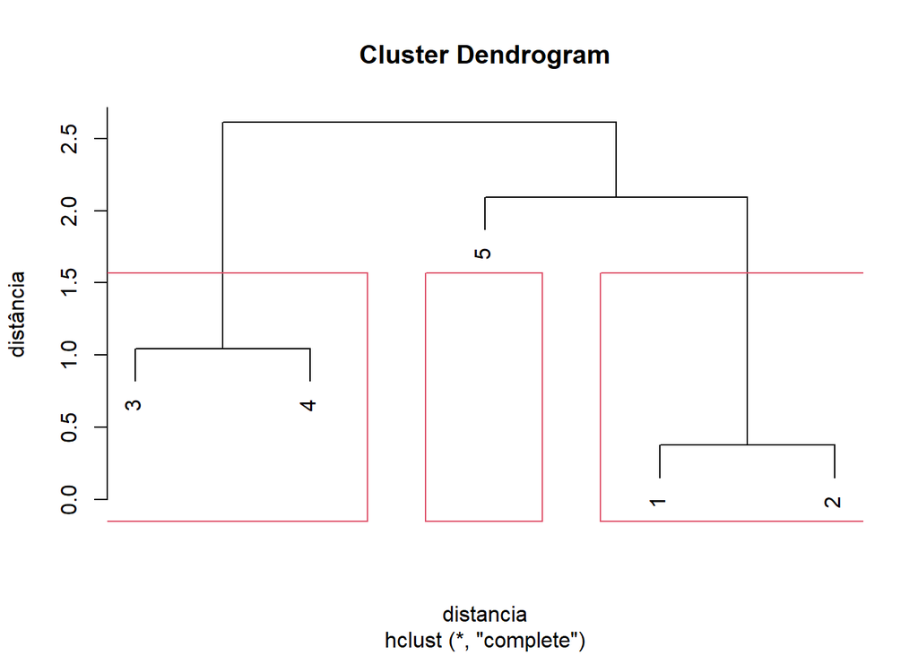

Cluster 1 (Candidatos 3 e 4): mais tempo de formação e passaram praticamente o mesmo tempo na mesma empresa - grupo Fiéis

Cluster 2 (Candidato 5): formado há bastante tempo, mas ainda está em busca de novas oportunidades - grupo dos “Em busca da felicidade”

Cluster 3 (Candidato 1 e 2): formado há pouco tempo e em busca de novas oportunidades - grupos dos juniores.